# Program

### Program outline

##### February 28, 2020:

- 13.00-17.00: Workshops

##### February 29, 2020:

- 10.00-18.00: CelebRation 2020 invited presentations.
- 18.00-20.00: Reception and celebration of R.

### Speakers

#### Peter Dalgaard

*Copenhagen Business School, Denmark*

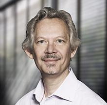

Peter is a member of the R core group and has been release manager since before the release of version 1.0.0, He is currently working towards the release of version 4.0.0.

#### Julia Silge

*StackOverflow, USA*

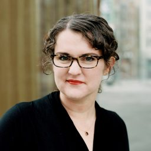

Julia is the author of the tidytext R package and has been a strong advocate for tidy structured text mining approaches in R.

#### Roger Bivand

*Norwegian School of Economics, Norway*

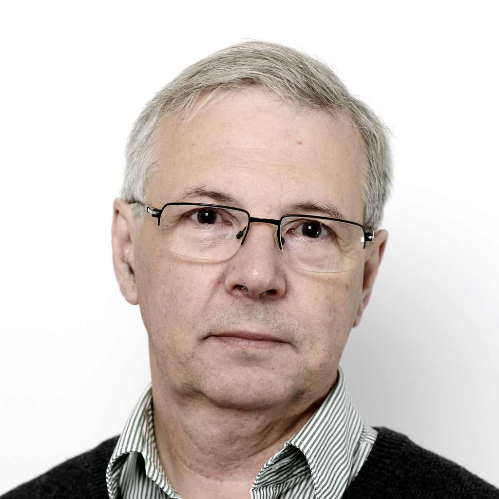

Roger has been active in the R community since 1997 and is the author of numerous R packages, particularly in the field the spatial data analysis. Roger is a member of the R foundation.

#### Heather Turner

*Freelance, UK*

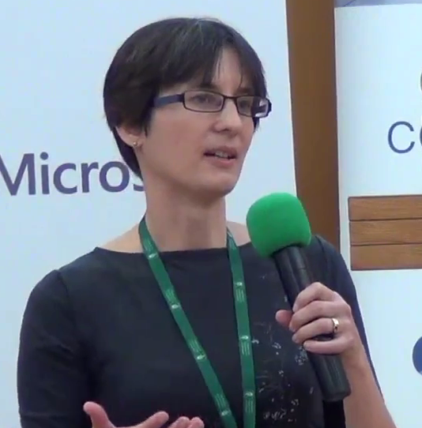

Heather is the chair of R Forwards - an R Foundation task force for underrepresented groups in the R community. Heather is also a member of the R foundation.

#### Therese Graversen

*IT University of Copenhagen, Denmark*

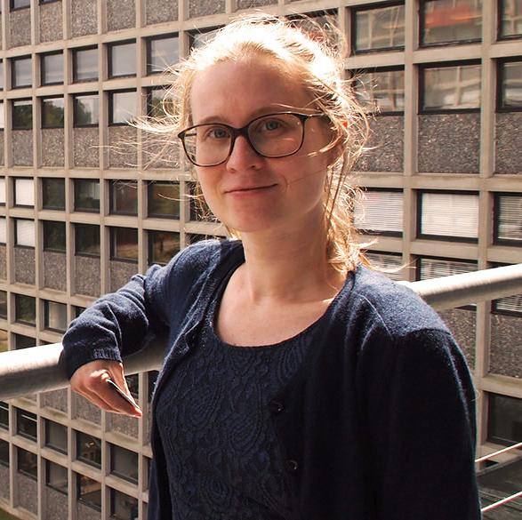

Therese has developed the DNAmixtures R package for analyzing DNA samples. She has used her research and the R package to help forensic investigations by serving as an expert witness for the British police several times.

### Workshop hosts

#### Dirk Eddelbuettel

*University of Illinois, USA*

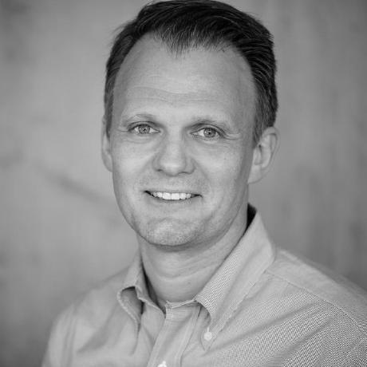

Dirk will host a workshop on the Rcpp library, which is a highly used API for integrating C++ code into R.

#### Thomas Lin Pedersen

*RStudio, Denmark*

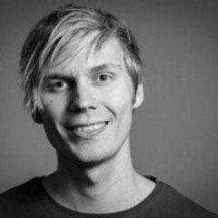

Thomas will host a workshop on the ggplot family of packages can be used for producing diverse and customizable graphics in R.